# Project2Stats2

Luke

7/17/2022

EDA Get data, view head, and summary.

```r
library(aplore3)
head(glow_bonemed, n=50)
```

```
##    sub_id site_id phy_id priorfrac age weight height      bmi premeno momfrac
## 1       1       1     14        No  62   70.3    158 28.16055      No      No
## 2       2       4    284        No  65   87.1    160 34.02344      No      No
## 3       3       6    305       Yes  88   50.8    157 20.60936      No     Yes
## 4       4       6    309        No  82   62.1    160 24.25781      No      No
## 5       5       1     37        No  61   68.0    152 29.43213      No      No
## 6       6       5    299       Yes  67   68.0    161 26.23356      No      No
## 7       7       5    302        No  84   50.8    150 22.57778      No      No
## 8       8       1     36       Yes  82   40.8    153 17.42919      No      No
## 9       9       1      8       Yes  86   62.6    156 25.72321      No      No
## 10     10       4    282        No  58   63.5    166 23.04398      No      No
## 11     11       6    315        No  67   67.6    153 28.87778      No     Yes
## 12     12       1     34        No  56  117.9    167 42.27473      No      No
## 13     13       6    315        No  59   67.1    162 25.56775      No      No
## 14     14       1     33        No  72   57.6    165 21.15702      No      No
```

[output cut: 87 more lines]

```r
#we will be testing for fracture
summary(glow_bonemed)
```

```
##      sub_id         site_id          phy_id       priorfrac      age
##  Min.   :  1.0   Min.   :1.000   Min.   :  1.00   No :374   Min.   :55.00
##  1st Qu.:125.8   1st Qu.:2.000   1st Qu.: 57.75   Yes:126   1st Qu.:61.00
##  Median :250.5   Median :3.000   Median :182.50             Median :67.00
##  Mean   :250.5   Mean   :3.436   Mean   :178.55             Mean   :68.56
##  3rd Qu.:375.2   3rd Qu.:5.000   3rd Qu.:298.00             3rd Qu.:76.00
##  Max.   :500.0   Max.   :6.000   Max.   :325.00             Max.   :90.00
##      weight           height           bmi        premeno   momfrac   armassist
##  Min.   : 39.90   Min.   :134.0   Min.   :14.88   No :403   No :435   No :312
##  1st Qu.: 59.90   1st Qu.:157.0   1st Qu.:23.27   Yes: 97   Yes: 65   Yes:188
##  Median : 68.00   Median :161.5   Median :26.42
##  Mean   : 71.82   Mean   :161.4   Mean   :27.55
##  3rd Qu.: 81.30   3rd Qu.:165.0   3rd Qu.:30.79
##  Max.   :127.00   Max.   :199.0   Max.   :49.08
##  smoke        raterisk     fracscore      fracture  bonemed   bonemed_fu
##  No :465   Less   :167   Min.   : 0.000   No :375   No :371   No :361
##  Yes: 35   Same   :186   1st Qu.: 2.000   Yes:125   Yes:129   Yes:139
##            Greater:147   Median : 3.000
##                          Mean   : 3.698
##                          3rd Qu.: 5.000
##                          Max.   :11.000
##  bonetreat
##  No :382
##  Yes:118
##
##
##
##
```

EDA continued Checking assumptions, no multicolinearity, decently large sample size

compare all with gg plot pairs.

#1 sub_id 2 site_id 3 phy_id 4 priorfrac 5 age 6 weight 7 height 8 bmi 9 premeno 10 momfrac 11 armassist 12 smoke 13 raterisk 14 fracscore 15 fracture 16 bonemed 17 bonemed_fu 18 bonetreat

sub_id will be removed because it is just the row number. Has nothing to do with fracture.

```r
library(GGally)
```

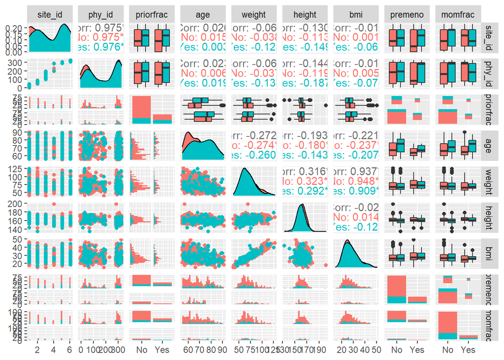

```r
library(aplore3)
#2-9
#ggpairs(glow_bonemed,columns=2:9,aes(colour=fracture))
#9-18
#ggpairs(glow_bonemed,columns=9:18,aes(colour=fracture))


#This is so we can compare all columns to one another in a plot that we can read.

#2-5 compared to 6-10
ggpairs(glow_bonemed,columns = c("site_id", "phy_id", "priorfrac", "age", "weight", "height", "bmi", "premeno", "momfrac"),
columnLabels = c("site_id", "phy_id", "priorfrac", "age", "weight", "height", "bmi", "premeno", "momfrac"),aes(colour=fracture))
```

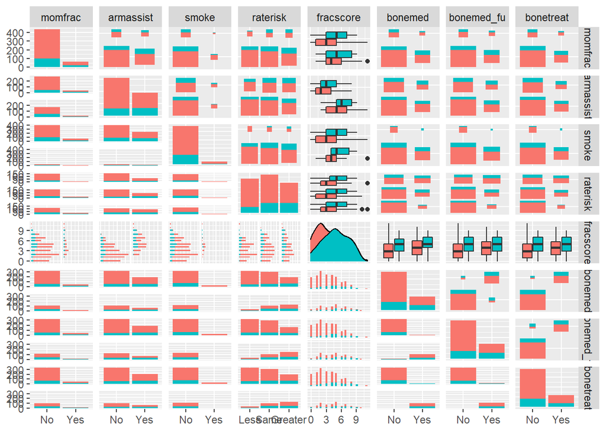

```r
#10-13 and 14, 16-18
ggpairs(glow_bonemed,columns = c("momfrac", "armassist", "smoke", "raterisk", "fracscore", "bonemed", "bonemed_fu", "bonetreat"),
columnLabels = c("momfrac", "armassist", "smoke", "raterisk", "fracscore", "bonemed", "bonemed_fu", "bonetreat"),aes(colour=fracture))
```

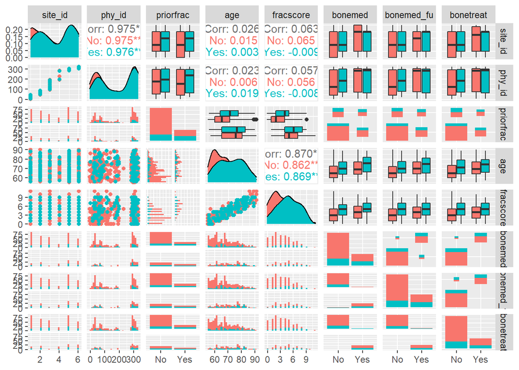

```r
#2-5 and 14, 16-18
ggpairs(glow_bonemed,columns = c("site_id", "phy_id", "priorfrac", "age", "fracscore", "bonemed", "bonemed_fu", "bonetreat"),
columnLabels = c("site_id", "phy_id", "priorfrac", "age", "fracscore", "bonemed", "bonemed_fu", "bonetreat"),aes(colour=fracture))
```

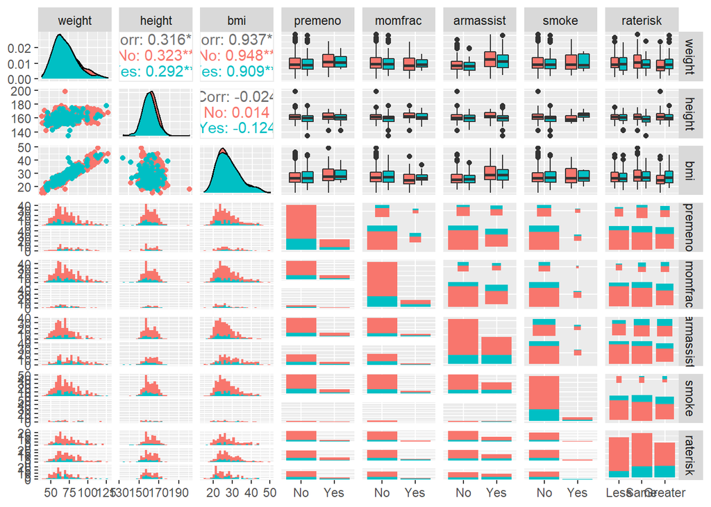

```r
#6-9, 10-13
ggpairs(glow_bonemed,columns = c("weight", "height", "bmi", "premeno", "momfrac", "armassist", "smoke", "raterisk"),
columnLabels = c("weight", "height", "bmi", "premeno", "momfrac", "armassist", "smoke", "raterisk"),aes(colour=fracture))
```

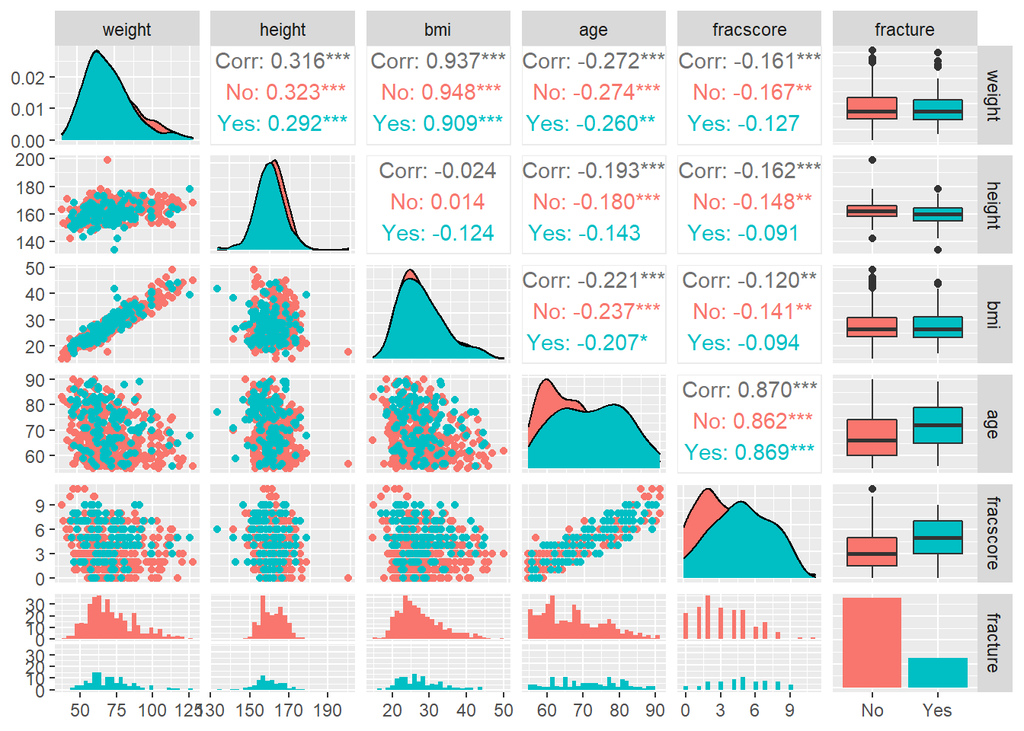

```r
#continuous variables and fracture
ggpairs(glow_bonemed,columns = c("weight", "height", "bmi", "age", "fracscore", "fracture"),
columnLabels = c("weight", "height", "bmi", "age", "fracscore", "fracture"),aes(colour=fracture))
```

Pick out some that are potentially colinear. A little more EDA for specific interests

Explore example predictors of interest vs fracture and example predictors vs predictors for deeper look into multi-collinearity.

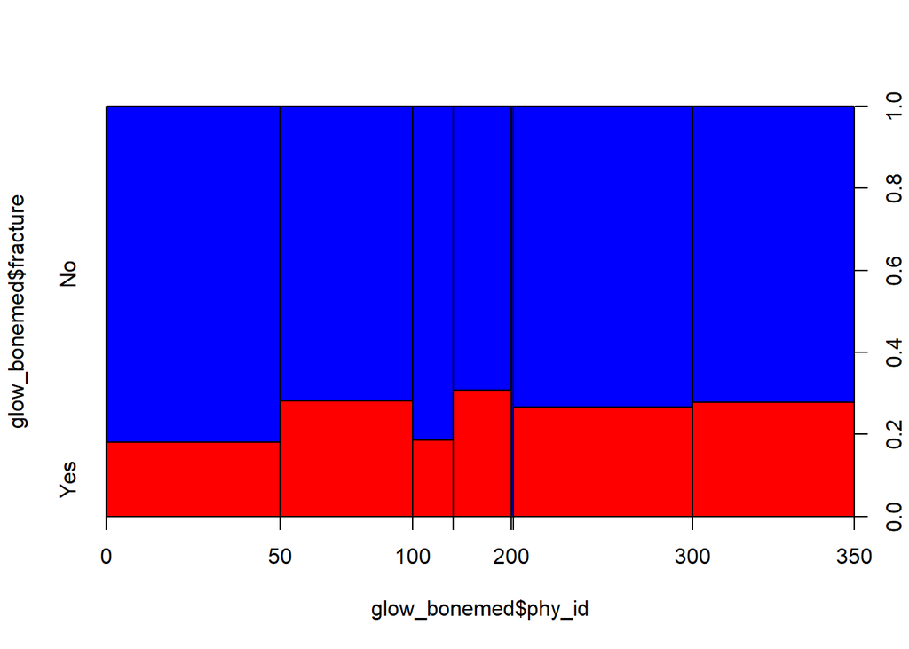

```r
library(aplore3)

### visualizing the relationship between specific predictors and fractures in the first year ###

#no distict relationship between fracture and site_id
#phy_id vs fracture
plot(glow_bonemed$fracture~glow_bonemed$phy_id,col=c("red","blue"))
```

```r
#Looks like as raterisk goes up, so does fracture
#raterisk (self-assigned) vs fracture proportion table and plot
prop.table(table(glow_bonemed$fracture,glow_bonemed$raterisk),2)
```

```
##
##            Less      Same   Greater
##   No  0.8323353 0.7419355 0.6666667
##   Yes 0.1676647 0.2580645 0.3333333
```

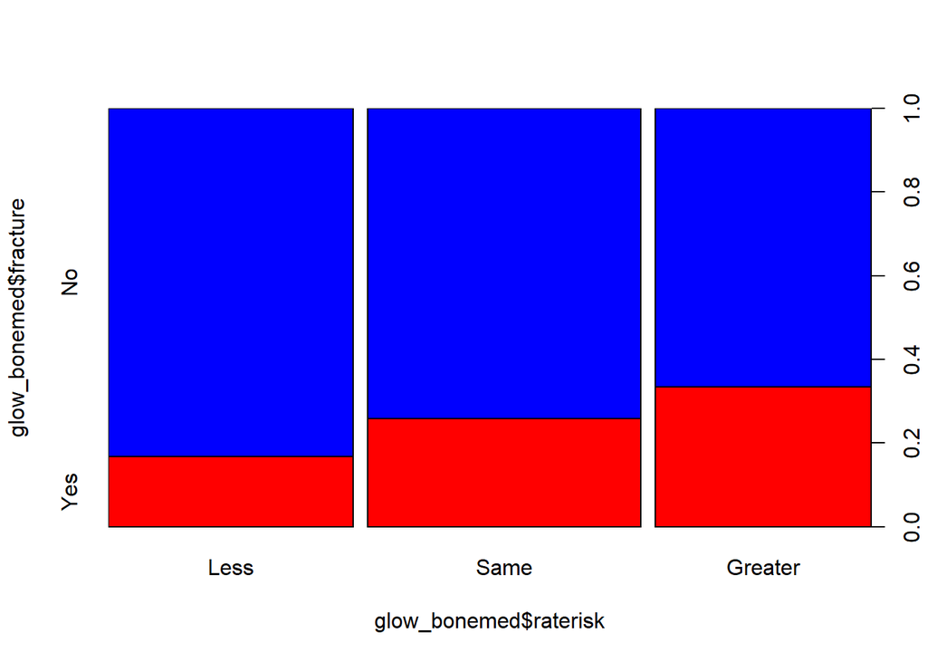

```r
plot(glow_bonemed$fracture~glow_bonemed$raterisk,col=c("red","blue"))
```

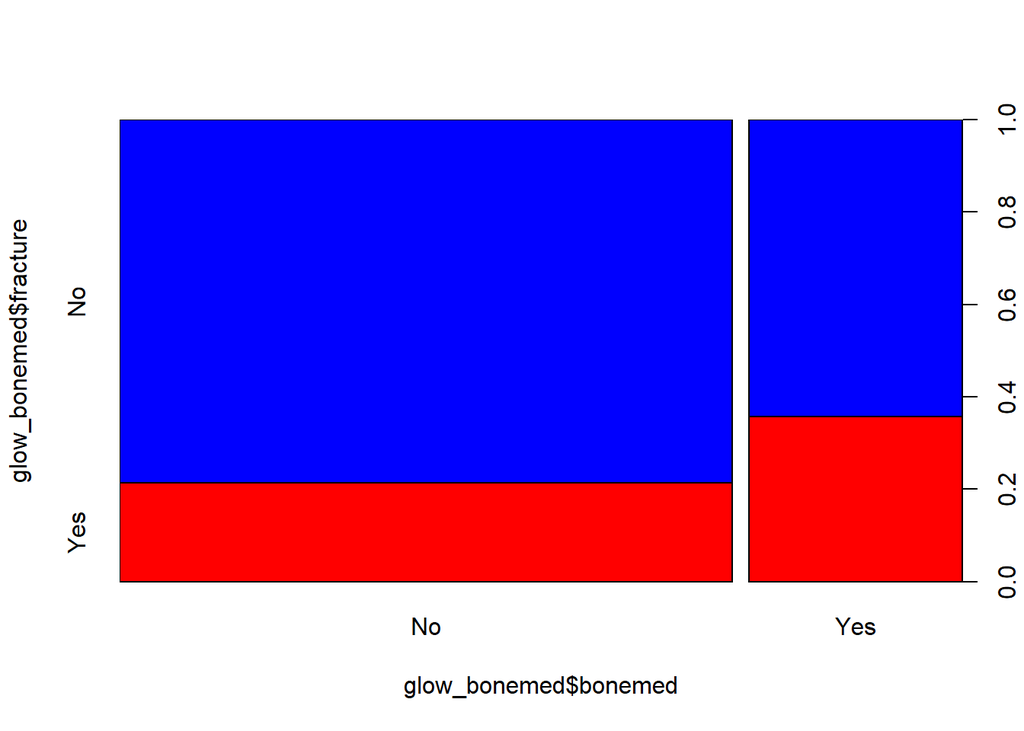

```r
#Looks like as bonemed goes up, so does fracture
#bonemed (at initial examination) vs fracture
plot(glow_bonemed$fracture~glow_bonemed$bonemed,col=c("red","blue"))
```

```r
### Checking for multicolinearity

#find info about age so we can split it into categories for data exploration only
summary(glow_bonemed$age)
```

```
##    Min. 1st Qu.  Median    Mean 3rd Qu.    Max.
##   55.00   61.00   67.00   68.56   76.00   90.00
```

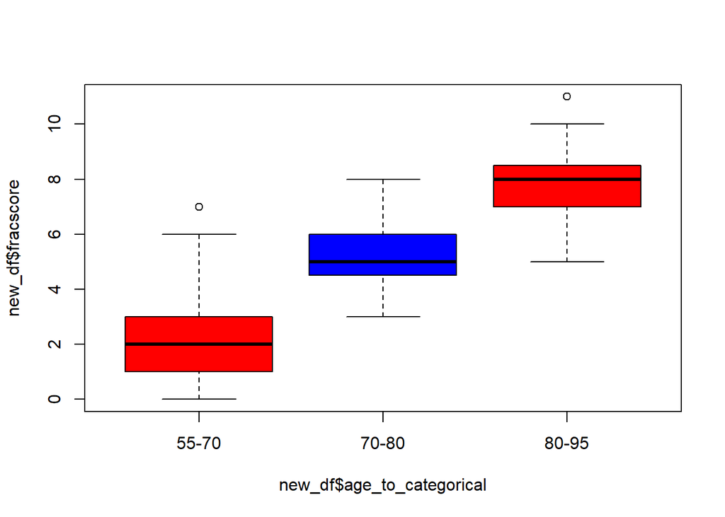

```r
#create categorical age variable for data exploration only
new_df <- glow_bonemed

new_df$age_to_categorical <- cut(new_df$age,
                       breaks=c(55, 70, 80, 95),
                       labels=c('55-70', '70-80', '80-95'))



#looks like there is a linear relationship between age and fracscore
#age and fracscore
plot(new_df$fracscore~new_df$age_to_categorical,col=c("red","blue"))
```

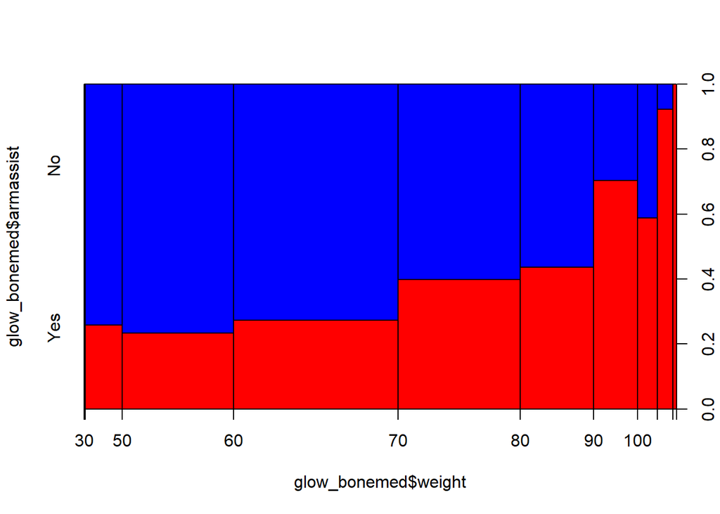

```r
#looks like there is a linear relationship between armassist and weight
#armassist and weight
plot(glow_bonemed$armassist~glow_bonemed$weight,col=c("red","blue"))
```

```r
#ggplot(glow_bonemed, aes(x=,y=, fill= fracture))
```

#1 sub_id 2 site_id 3 phy_id 4 priorfrac 5 age 6 weight 7 height 8 bmi 9 premeno 10 momfrac 11 armassist 12 smoke 13 raterisk 14 fracscore 15 fracture 16 bonemed 17 bonemed_fu 18 bonetreat

You can see there is minor co linearity between some of the independent variables. Phy_id and site_id, weight and bmi, Maybe bonemed and momfrac, armassist,smoke,raterisk possibly colinear with weight,height,bmi,premeno, age and fracscore

First off sub_id should be removed because it is just the row number. Has nothing to do with fracture. correlations between suspects and vif scores and then create a simple model